# L’influence du sport sur les individus

Rosse Mathys - Siette Romain

16 décembre 2022

# Introduction

Nous savons que le sport impacte notre vie et notre façon d’être, mais à quel point ? Aujourd’hui, nous allons répondre à cette interrogation qui nous turlupine intensément. Le sport nous influence-t-il réellement ?

Les répondants pouvaient choisir entre plusieurs sports et même en ajouter certains. Nous avons décidé d’omettre les variables contenant les ajouts d’autres sports pour recentrer l’étude.

Donc dans un premier temps nous allons etudier si la pratique d’un **sport collectif** solicite davantage **l’entraide** ou non.

Pour se faire nous étudierons la situation de 171 étudiants venant de toutes fillières.

D’abord nous allons réaliser une répartition des répondants en fonction des sports collectifs ou non que chacun pratique, puis nous allons donc les confronter sur le point de vue l’entraide.

Mais avant cela, regardons ce que les étudiants pratiquent comme activité sportive :

# Quels sports faites-vous ?

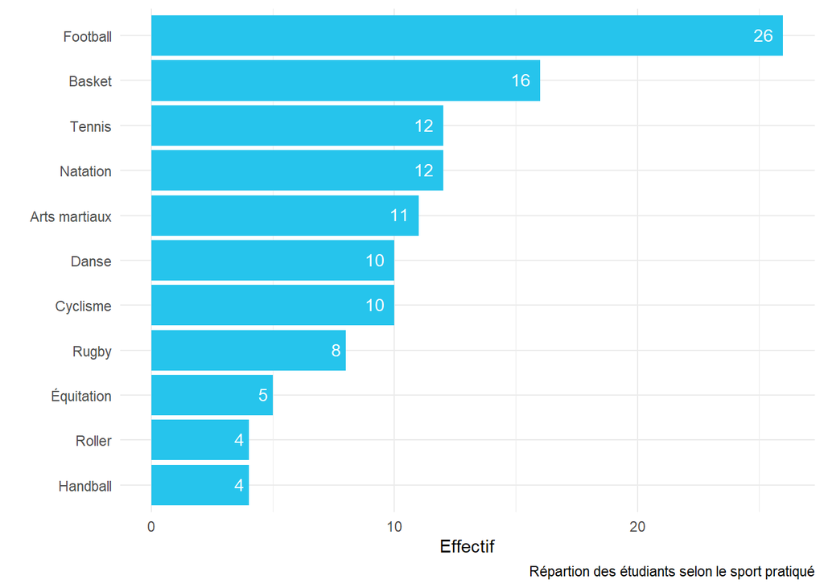

Nous observons que le sport le plus pratiqué est le football. Mais la multiplicté des sports cités permet de distinguer *2 groupes distincts* ;

**-Les pratiquants de sports collectifs**

**-Les pratiquants de sports individuels**

# Plutôt sport individuel ou collectif ?

Les 2 types de sports étant maintenant différenciés. Il faut regarder de plus proche ce que font ces jeunes gens.

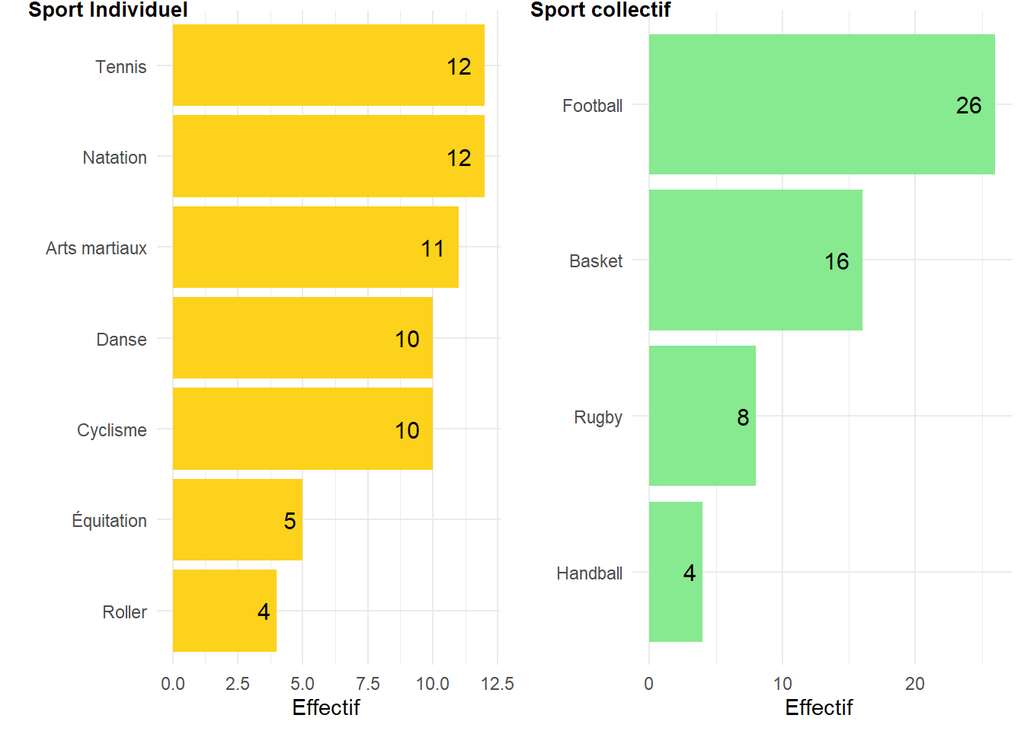

Maintenant que l’on y voit un peu plus clair. Nous pouvons regrouper tout cela dans un tableau d’effectif global en fonction du sport pratiqué.

Type de sport pratiqué par les répondants

| Type de sport | Effectif |
| --- | --- |
| sport collectif | 36 |
| sport individuel | 21 |

Il y a aux vues des résultats **moins** de pratiquants de sports individuels que de pratiquants de sport collectifs.

Nous allons donc tester s’il y a un sport qui prédomine sur la préférence à l’entraide.

# Les sports collectifs nous font préférer l’entraide ?

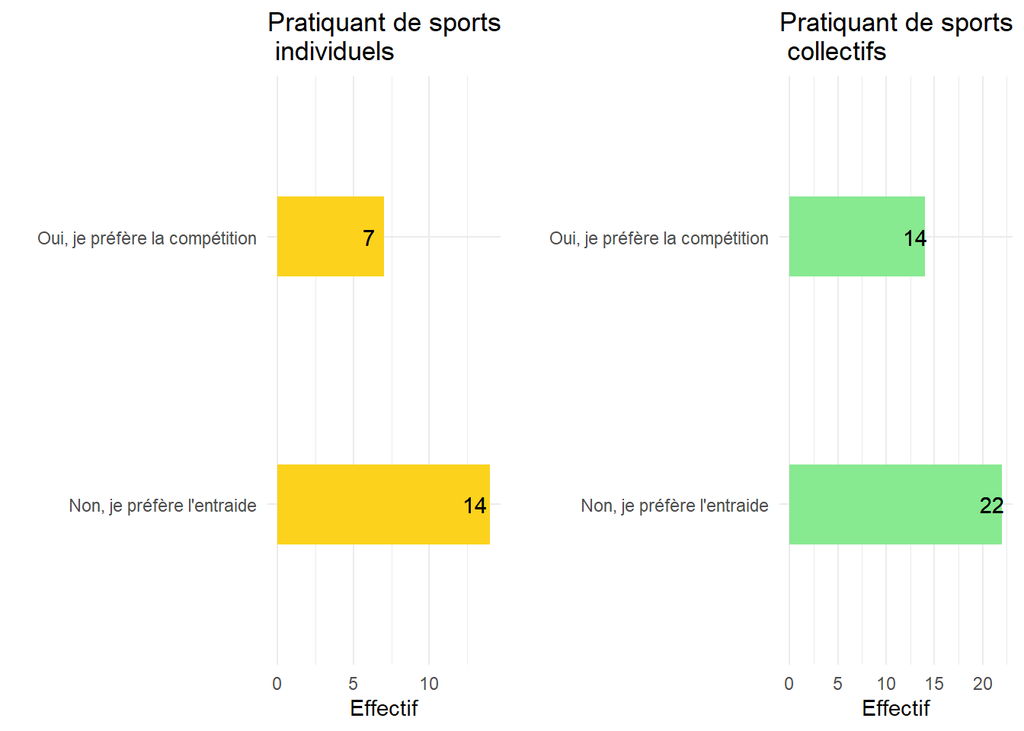

Après l’étude des graphiques ci-dessus on en retient que pour les répondants exercant un sport individuel il y a 66.67% qui préfèrent l’entraide à la compétition.

Cependant pour les pratiquant de sports collectifs il y a, à la surprise générale, que 61.11% des gens qui préfèrent l’entraide à la compétition.

Les données déduites sont trop proche pour pouvoir en tirer de nettes conclusions. *Le sport pratiqué n’a donc aucun impact sur la tendance vers l’entraide ou la compétition.*

# Le sport influence-t-il notre bonheur ?

Pour nous, les journées productives sont souvent source de bonheur et de satifaction lorsqu’elles prennent fin.

On dit qu’elles le sont après avoir effectué toutes les taches que l’on s’était dis de faire comme réviser la microéconomie pour avoir 4 à la fin, ou suivre correctement le **formidable** TD de logiciel R de madame Scholler par exemple…

En tous cas, une bonne séance de sport fait partie intégrante de tout ce mécanisme dans notre définition personnelle mais est-ce vraiment le cas pour tout le monde ? Le sport nous rend heureux ?

Répartition des répondants selon leur niveau de bonheur et leur sportivité

|  | Niveau de bonheur 0 | Niveau de bonheur 1 | Niveau de bonheur 2 | Niveau de bonheur 3 | Niveau de bonheur 4 | Niveau de bonheur 5 | Niveau de bonheur 6 | Niveau de bonheur 7 | Niveau de bonheur 8 | Niveau de bonheur 9 | Niveau de bonheur 10 | Total |
| --- | --- | --- | --- | --- | --- | --- | --- | --- | --- | --- | --- | --- |
| Non-sportif | 3 | 0 | 0 | 6 | 1 | 3 | 4 | 17 | 10 | 4 | 3 | 51 |
| Sportif | 4 | 2 | 2 | 8 | 1 | 18 | 15 | 40 | 18 | 4 | 8 | 120 |
| Total | 7 | 2 | 2 | 14 | 2 | 21 | 19 | 57 | 28 | 8 | 11 | 171 |

Note:  
<sup>1</sup> La colonne avec le niveau de bonheur à 7 est celle avec le plus de votant.

Premièrement, on observe que les répondants sont plutôt sportifs. Sur l’ensemble des réponses récoltées les sportifs sont **2,35 fois** plus nombreux que les non-sportifs.

Un bonheur absolu est compliqué à exprimer (soit une note 7>) car le bonheur est variable en fonction de la situation et peut être perçu differement selon les personnes.

Il est donc normal qu’on retrouve une forte densité de réponse vers le niveau 7 qui constitue un niveau de bonheur assez positif. La colonne regroupe toutes les personnes étant heureuses mais notifiant des faits plus ou moins graves en fonction de l’appréciation de chacun impactant leurs vies ce qui peut expliquer qu’elles ne notent pas leur bonheur à 10.

**Les explications émisent ci-dessus sont nettement plus visibles grâce au graphique suivant :**

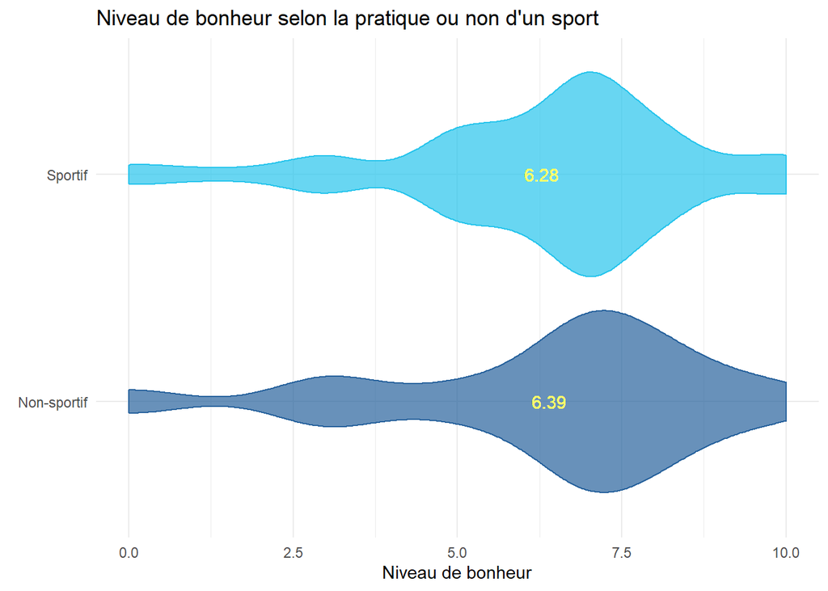

Le graphique illustre le niveau de densité des réponses selon le niveau de bonheur choisi et y constitue une moyenne selon la sportivité ou non des répondants.

On voit que les moyennes des niveaux de bonheur par sportivité sont donc approximativement les mêmes.

*Le sport n’aurait aucun impact sur le bonheur ?* Nous allons effectuer une série de test afin de vérifier ces affirmations.

## Tests statistiques

L’ojectif de ces tests sont de nous permettre de savoir si le fait d’être sportif ou non influence notre bonheur.

Pour cela nous allons tout d’abord tester l’égalité des variances; une fois cette égalité vérifiée on peut procéder au test d’égalité des moyennes en conservant l’hypothèse préalablement vérifiée.

### Test d’égalité des variances

-**H0**:le ratio des variances est égal a 1

-**H1**:le ratio des variances est différent de 1

On observe que la p-value vaut **0.3695** qui est superieure au risque **0.05**

Donc au risque de **5%** on conserve l’hypothèse **H0** d’égalité des variances entre le niveau de bonheur des sportifs et des non-sportifs

### Test d’égalité des moyennes

-**H0**: les moyennes sont égales

-**H1**: les moyennes sont significativement différentes

On observe que la p-value vaut **0.7768** qui est superieure au risque **0.05**

Donc au risque de **5%** on conserve l’hypothèse **H0** de l’égalité des moyennes

Ainsi on peut conclure que les moyennes du bonheur entre les sportifs et non sportifs peuvent être considérée comme égale donc le fait d’être sportif ou non n’influence pas le bonheur.

# Des sportifs fumeurs, est-ce compatible ?

Dans l’imaginaire collectif être sportif et fumeur n’a jamais été compatible, en même temps cracher ses poumons à chaque efforts c’est pas le top !

Mais dans la réalité est-ce qu’être sportif et fumeur est si rare que ça ?

Répartition des répondants selon leur sportivité et le fait qu’ils fument ou non

|  | Sportif | Non-sportif | Total |
| --- | --- | --- | --- |
| Non | 96 | 40 | 136 |
| Oui | 24 | 11 | 35 |
| Total | 120 | 51 | 171 |

Le tableau ne nous permet pas de conclure. Les résultats auraient pu être concluant en ayant eu des données sur les sportifs reguliés et les sportifs occasionnels.

L’hypothèse de base aurait été que dans le groupe des sportifs il y ait moins de fumeurs que dans le groupe des non-sportifs.

## Test statistique

Le but de ce test va être de voir si le fait d’être fumeur influence le fait de faire du sport, pour cela on va effectuer un test d’indépendance sur nos deux variables.

### Test d’indépendance

-**H0**: les variables sont indépendantes

-**H1**: les variables sont dépendantes

On observe que la p-value vaut **0.9797** qui est superieure au risque **0.05**.

Donc au risque de **5%** on conserve l’hypothèse **H0** d’indépendance des deux variables.

Ainsi, on peut conclure que dans notre echantillon le fait d’être sportif ou non n’a pas d’impact sur le fait d’être fumeur.

# Conclusion

Nous partions de l’idée que le sport avait un réel impact sur la vie et les comportements des gens. Finalement, l’influence du sport sur notre vie et nos comportements est moindre.

Cela remet donc notre hypothèse en question car selon notre étude ;

**-Le type de sport pratiqué (collectif ou individuel) n’a pas d’impact sur la préférence à l’entraide**

**-Le sport n’a pas d’influence sur le niveau de bonhneur des répondants**

**-Être sportif ne réduit pas le fait d’être fumeur**

*Merci d’avoir pris le temps de nous lire !* *Nous vous souhaitons donc un joyeux Noël, une bonne année 2023 et de bonnes galettes des rois !*